# CSCI E-63C: Midterm Exam

# Introduction

*The goal of the midterm exam is to apply some of the methods covered in our course by now to a new dataset. We will work with the data characterizing real estate valuation in New Taipei City, Taiwan that is available at [UCI ML repository](https://archive.ics.uci.edu/ml/datasets/Real+estate+valuation+data+set) as well as at this course website on canvas. The overall goal will be to use data modeling approaches to understand which attributes available in the dataset influence real estate valuation the most. The outcome attribute (Y – house price of unit area) is inherently continuous, therefore representing a regression problem.*

*For more details please see dataset description available at UCI ML or corresponding [HTML file](https://canvas.harvard.edu/courses/79740/files/10495424/download) on canvas website for this course. For simplicity, clarity and to decrease your dependency on the network reliability and UCI ML or canvas website availability during the time that you will be working on this project you are advised to download data made available on the canvas website to your local folder and work with the local copy. The dataset at UCI ML repository as well as its copy on our course canvas website is provided as an Excel file [Real estate valuation data set.xlsx](https://canvas.harvard.edu/courses/79740/files/10495420/download) – you can either use `read_excel` method from R package `readxl` to read this Excel file directly or convert it to comma or tab-delimited format in Excel so that you can use `read.table` on the resulting file with suitable parameters (and, of course, remember to double check that in the end what you have read into your R environment is what the original Excel file contains).*

*Finally, as you will notice, the instructions here are much terser than in the previous problem sets. We expect that you use what you’ve learned in the class to complete the analysis and draw appropriate conclusions based on the data. The approaches that you are expected to apply here have been exercised in the preceeding weeks – please feel free to consult your submissions and/or official solutions as to how they have been applied to different datasets. As always, if something appears to be unclear, please ask questions – note that we may decide to change your questions to private mode as we see fit, if in our opinion they reveal too many specific details of the problem solution.*

# Sub-problem 1: load and summarize the data (20 points)

*Download and read in the data, produce numerical and graphical summaries of the dataset attributes, decide whether they can be used for modeling in untransformed form or any transformations are justified, comment on correlation structure and whether some of the predictors suggest relationship with the outcome.*

```r
#packages

library(readxl)
library(car)
library(dplyr)
```

```r
library(ggplot2)
library(glmnet)
library(leaps)
```

```r
#load data
file = read_excel("Real estate valuation data set.xlsx")
names(file)
```

```
## [1] "No"
## [2] "X1 transaction date"
## [3] "X2 house age"
## [4] "X3 distance to the nearest MRT station"
## [5] "X4 number of convenience stores"
## [6] "X5 latitude"
## [7] "X6 longitude"
## [8] "Y house price of unit area"
```

```r
data = subset(file, select = -No) #remove item number column

#data summaries
summary(data) #numerical
```

```
##  X1 transaction date  X2 house age    X3 distance to the nearest MRT station
##  Min.   :2013        Min.   : 0.000   Min.   :  23.38
##  1st Qu.:2013        1st Qu.: 9.025   1st Qu.: 289.32
##  Median :2013        Median :16.100   Median : 492.23
##  Mean   :2013        Mean   :17.713   Mean   :1083.89
##  3rd Qu.:2013        3rd Qu.:28.150   3rd Qu.:1454.28
##  Max.   :2014        Max.   :43.800   Max.   :6488.02
##  X4 number of convenience stores  X5 latitude     X6 longitude
##  Min.   : 0.000                  Min.   :24.93   Min.   :121.5
##  1st Qu.: 1.000                  1st Qu.:24.96   1st Qu.:121.5
##  Median : 4.000                  Median :24.97   Median :121.5
##  Mean   : 4.094                  Mean   :24.97   Mean   :121.5
##  3rd Qu.: 6.000                  3rd Qu.:24.98   3rd Qu.:121.5
##  Max.   :10.000                  Max.   :25.01   Max.   :121.6
##  Y house price of unit area
##  Min.   :  7.60
##  1st Qu.: 27.70
##  Median : 38.45
##  Mean   : 37.98
##  3rd Qu.: 46.60
##  Max.   :117.50
```

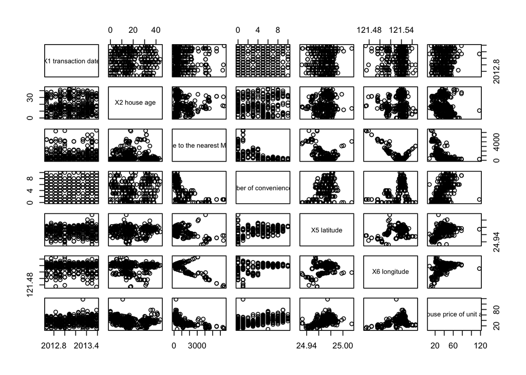

```r
plot(data) #graphical
```

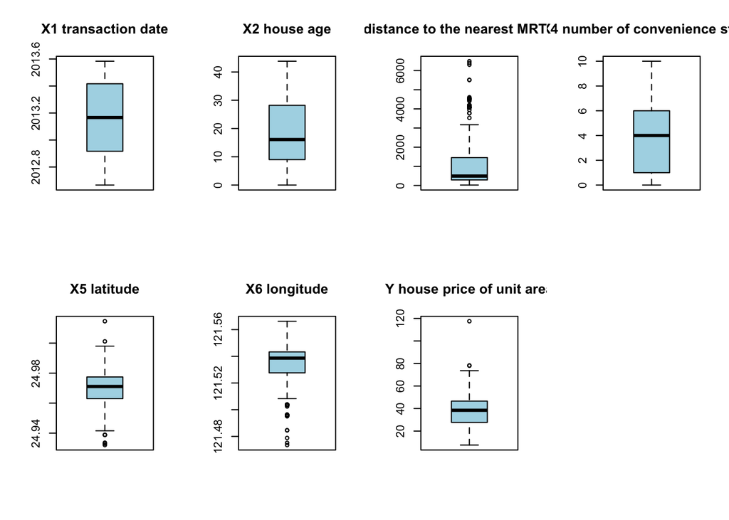

```r
par(mfrow=c(2,4))
for(x in 1:7){
  boxplot(data[,x], col = 'lightblue', main = names(data)[x])
}
```

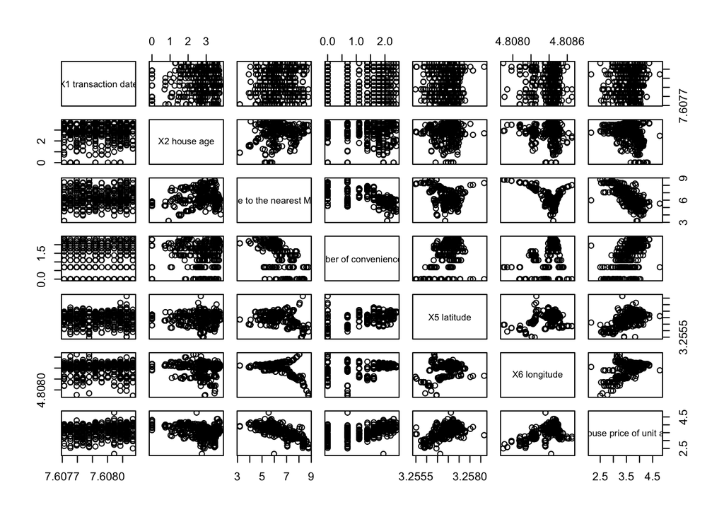

```r
#correlations
cor = cor(data)

order = order(abs(cor[,7]), decreasing = T) #reorder by strongest correlation w outcome Y
cor = cor[order, ]

#log transformation
logdata = log(data + 1)
plot(logdata)
```

[output not shown]

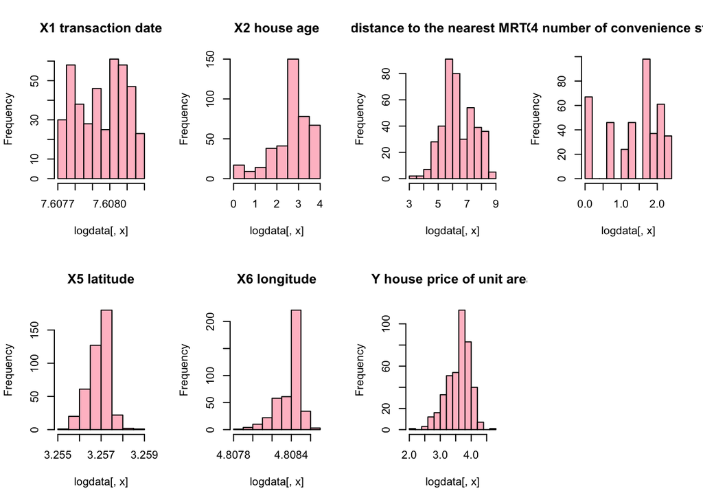

```r
par(mfrow=c(2,4))
for(x in 1:7){
  hist(logdata[,x], col = 'pink', main = names(logdata)[x])
}

logcor = cor(logdata)
logcor = logcor[order, ]

#un/transformed correlation comparison
cortable = round(cbind(untransformed = cor[,7], transformed = logcor[,7]), 3); cortable
```

# Sub-problem 2: multiple linear regression model (25 points)

*Using function `lm` fit model of outcome as linear function of all predictors in the dataset. Present and discuss diagnostic plots. Report 99% confidence intervals for model parameters that are statistically significantly associated with the outcome and discuss directions of those associations. Obtain mean prediction (and corresponding 90% confidence interval) for a new observation with each attribute set to average of the observations in the dataset. Describe evidence for potential collinearity among predictors in the model.*

```r
#fit model
m = lm(logdata$`Y house price of unit area` ~ ., logdata)
summary(m)
```

```
##
## Call:
## lm(formula = logdata$`Y house price of unit area` ~ ., data = logdata)
##
## Residuals:
##      Min       1Q   Median       3Q      Max
## -1.50309 -0.10727  0.01492  0.09771  0.98885
##
## Coefficients:
##                                            Estimate Std. Error t value Pr(>|t|)
## (Intercept)                              -4.935e+03  7.116e+02  -6.936 1.59e-11
## `X1 transaction date`                     3.400e+02  6.977e+01   4.873 1.58e-06
## `X2 house age`                           -8.856e-02  1.129e-02  -7.845 3.85e-14
## `X3 distance to the nearest MRT station` -1.545e-01  1.391e-02 -11.104  < 2e-16
## `X4 number of convenience stores`         5.141e-02  1.725e-02   2.981  0.00305
## `X5 latitude`                             2.455e+02  2.409e+01  10.192  < 2e-16
## `X6 longitude`                            3.232e+02  1.030e+02   3.139  0.00182
##
## (Intercept)                              ***
## `X1 transaction date`                    ***
## `X2 house age`                           ***
## `X3 distance to the nearest MRT station` ***
## `X4 number of convenience stores`        **
## `X5 latitude`                            ***
## `X6 longitude`                           **
## ---
## Signif. codes:  0 '***' 0.001 '**' 0.01 '*' 0.05 '.' 0.1 ' ' 1
##
## Residual standard error: 0.1961 on 407 degrees of freedom
## Multiple R-squared:  0.7365, Adjusted R-squared:  0.7326
## F-statistic: 189.6 on 6 and 407 DF,  p-value: < 2.2e-16
```

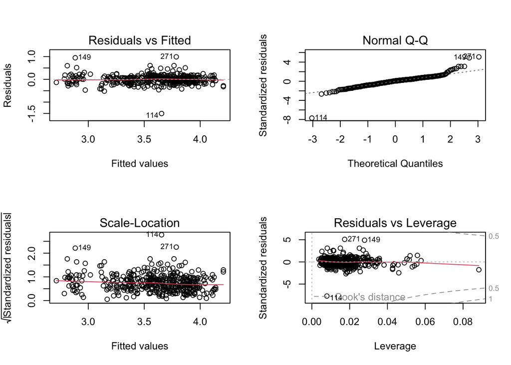

```r
#diagnostic plots
par(mfrow = c(2,2))
plot(m)
```

*The residuals vs fitted plot shows a horizontal red line and data points relatively evenly spread on the y-axis, which suggests that there is not a significant non-linear trend. The normal Q-Q plot shows a heavier tail, particularly on the right side, suggesting more data on that side compared to the center. The scale-location plot shows a relatively straight, horizontal red line with evenly spread data points, suggesting linearity. Both the residuals vs fitted and scale-location plots show a gap in data points on the lower end. Residuals vs leverage shows Cook’s distance 0.5 and 1 lines, with one data point with much higher leverage than the rest; however, no data points fall outside of Cook’s lines.*

```r
#99% confidence intervals
round(confint(m, level = 0.99),3)
```

```
##                                              0.5 %    99.5 %
## (Intercept)                              -6776.972 -3094.017
## `X1 transaction date`                      159.430   520.537
## `X2 house age`                              -0.118    -0.059
## `X3 distance to the nearest MRT station`    -0.191    -0.118
## `X4 number of convenience stores`            0.007     0.096
## `X5 latitude`                              183.197   307.889
## `X6 longitude`                              56.704   589.649
```

```r
#predictions
pred = predict(m, interval = 'confidence', level = 0.9)
mean(pred)
```

```
## [1] 3.59687
```

```r
#collinearity
vif(m)
```

```
##                    `X1 transaction date`
##                                 1.024979
##                           `X2 house age`
##                                 1.066357
## `X3 distance to the nearest MRT station`
##                                 2.593128
##        `X4 number of convenience stores`
##                                 1.879408
##                            `X5 latitude`
##                                 1.424133
##                           `X6 longitude`
##                                 1.786943
```

*The 99% confidence intervals show positive values for transaction date, convenience stores, latitude, and longitude, and negative values for house age and distance to the nearest MRT station.*

*VIF scores of approximately 1 for transaction date and house age suggest no collinearity. The remaining predictors have VIF scores between 1.4 and 2.6, which may suggest moderate correlation, but not a problematic level of collinearity. MRT station distance shows the highest VIF score.*

# Sub-problem 3: choose optimal models by exhaustive, forward and backward selection (20 points)

*Use `regsubsets` from library `leaps` to choose optimal set of variables for modeling real estate valuation and describe differences and similarities between attributes deemed most important by these approaches.*

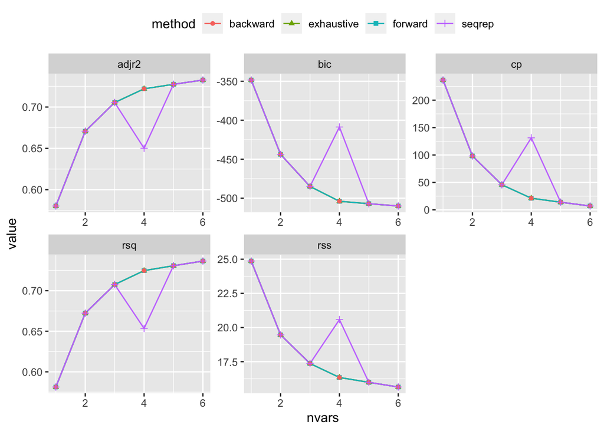

```r
summaryMetrics = NULL
whichAll = list()

for (method in c("exhaustive", "forward", "backward", "seqrep")){
  results = regsubsets(logdata$`Y house price of unit area` ~ ., data = logdata, method = method, nvmax = 6)
  sumres = summary(results)
  whichAll[[method]] = sumres$which

  for (metric in c("rsq", "rss", "adjr2", "cp", "bic")) {
    summaryMetrics = rbind(summaryMetrics,
                           data.frame(method = method,
                                      metric = metric,
                                      nvars = 1:length(sumres[[metric]]),
                                      value = sumres[[metric]]))
  }
}

ggplot(summaryMetrics, aes(x = nvars, y = value, shape = method, color = method)) + geom_path() + geom_point() + facet_wrap(~metric, scales = "free") + theme(legend.position = "top")
```

*All of the methods are in agreement for the model selection, with the exception of seqrep, which chose a much inferior model with 4 variables. Using all 6 variables shows the highest adjusted R2 and R2, and the lowest BIC, Cp, and RSS.*

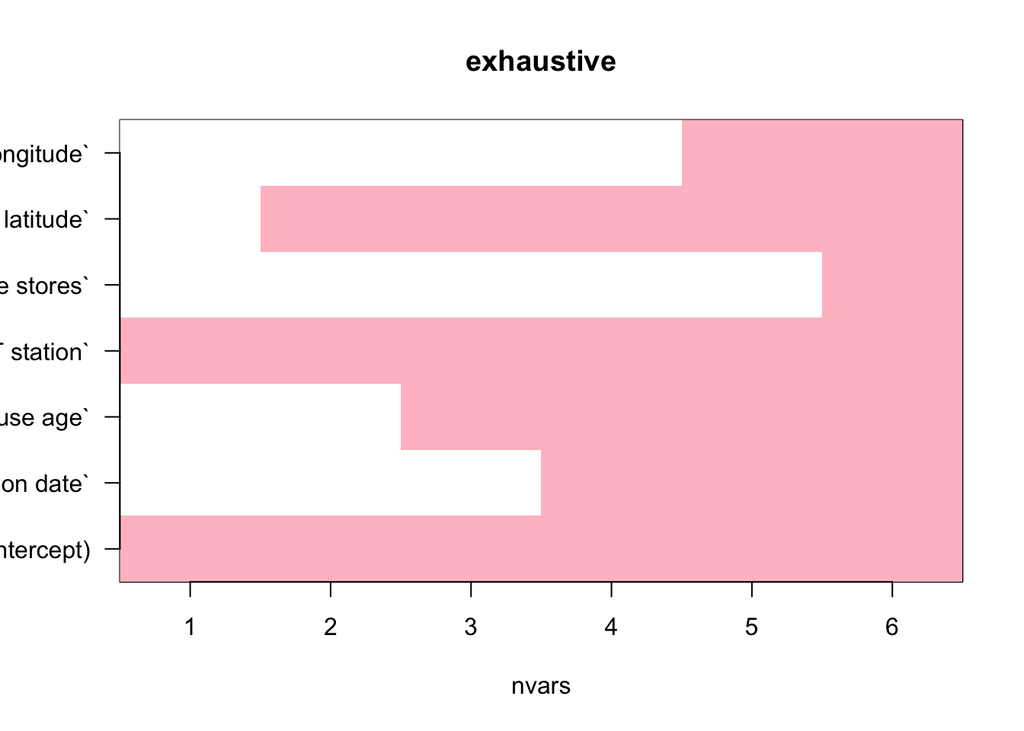

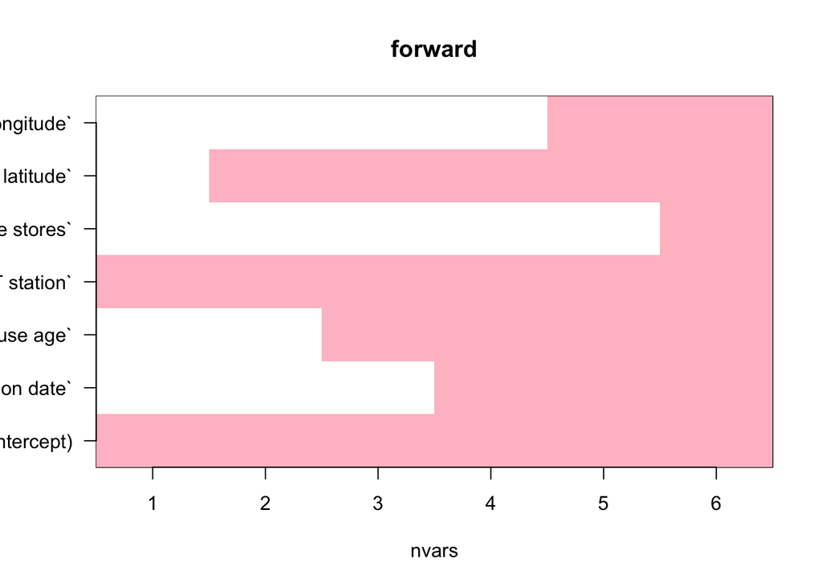

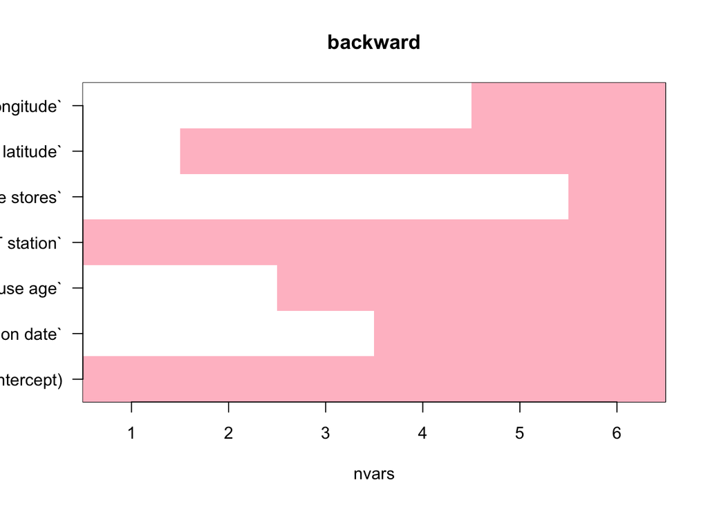

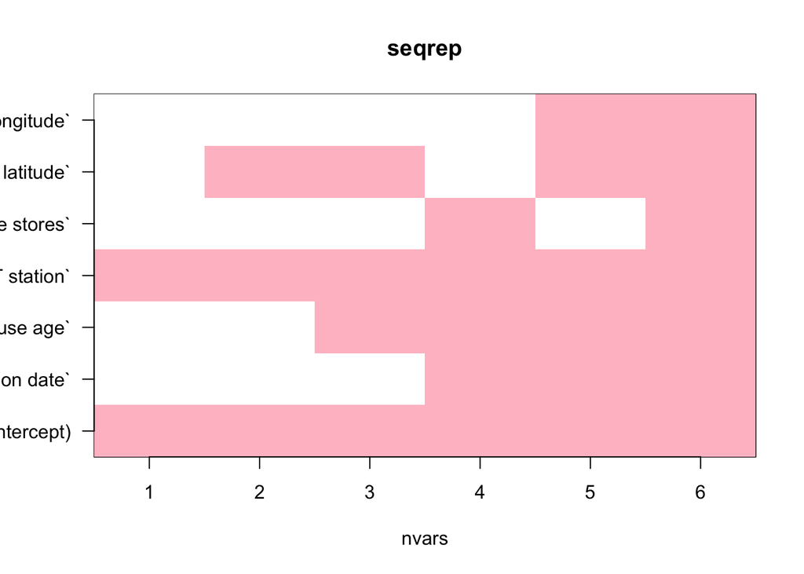

```r
for (method in names(whichAll)){
  image(1:nrow(whichAll[[method]]),
        1:ncol(whichAll[[method]]),
        whichAll[[method]], xlab = "nvars", ylab = "",
        xaxt = "n", yaxt = "n", breaks = c(-0.5, 0.5, 1.5),
        col = c("white", "pink"), main = method)
  axis(1, 1:nrow(whichAll[[method]]), rownames(whichAll[[method]]))
  axis(2, 1:ncol(whichAll[[method]]), colnames(whichAll[[method]]), las = 2)

}
```

*All of the methods agree that distance to the nearest MRT station is the most important attribute, followed by latitude, house age, transaction date, longitude, and number of convenience stores. However, seqrep ranks convenience stores higher compared to backward, forward, and exhaustive methods.*

# Sub-problem 4: optimal model by resampling (20 points)

*Use cross-validation or any other resampling strategy of your choice to estimate test error for models with different numbers of variables. Compare and comment on the number of variables deemed optimal by resampling versus those selected by `regsubsets` in the previous task.*

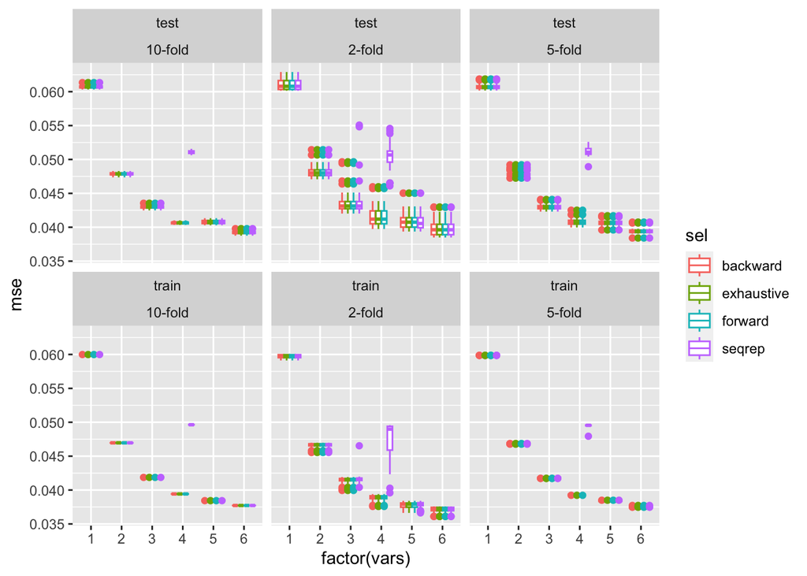

```r
cv <- function(nTries=30,kXval=5) {
  retRes <- NULL
  for ( iTry in 1:nTries ) {
    xvalFolds <- sample(rep(1:kXval,length.out=nrow(logdata)))
    for ( jSelect in c("exhaustive", "backward", "forward", "seqrep") ) {
      mthdTestErr2 <- NULL
      mthdTrainErr2 <- NULL
      mthdTestFoldErr2 <- NULL
      for ( kFold in 1:kXval ) {
        rsTrain <- regsubsets(`Y house price of unit area`~.,logdata[xvalFolds!=kFold,],nvmax=6,method=jSelect)
        nVarTestErr2 <- NULL
        nVarTrainErr2 <- NULL
        for ( kVarSet in 1:6 ) {
          kCoef <- coef(rsTrain,id=kVarSet)
          testPred <- model.matrix(`Y house price of unit area`~.,logdata[xvalFolds==kFold,])[,names(kCoef)] %*% kCoef
          nVarTestErr2 <- cbind(nVarTestErr2,(testPred-logdata[xvalFolds==kFold,"Y house price of unit area"])^2)
          trainPred <- model.matrix(`Y house price of unit area`~.,logdata[xvalFolds!=kFold,])[,names(kCoef)] %*% kCoef
          nVarTrainErr2 <- cbind(nVarTrainErr2,(trainPred-logdata[xvalFolds!=kFold,"Y house price of unit area"])^2)
        }
        mthdTestErr2 <- rbind(mthdTestErr2,nVarTestErr2)
        mthdTestFoldErr2 <- rbind(mthdTestFoldErr2,colMeans(nVarTestErr2))
        mthdTrainErr2 <- rbind(mthdTrainErr2,nVarTrainErr2)
      }
      retRes <- rbind(retRes,
                    data.frame(sim=iTry,sel=jSelect,vars=1:ncol(nVarTrainErr2),mse=colMeans(mthdTrainErr2),trainTest="train"),
                    data.frame(sim=iTry,sel=jSelect,vars=1:ncol(nVarTrainErr2),mse=colMeans(mthdTestErr2),trainTest="test"))

    }
  }
  retRes
}

dfTmp <- rbind(data.frame(cv(30,kXval=2),xval="2-fold"),
               data.frame(cv(30,kXval=5),xval="5-fold"),
               data.frame(cv(30,kXval=10),xval="10-fold"))
ggplot(dfTmp,aes(x=factor(vars),y=mse,colour=sel)) + geom_boxplot()+facet_wrap(~trainTest+xval)
```

*Cross validation shows the lowest MSE with 6 variables for both testing and training data, which agrees with the previous task. Seqrep shows higher error with 4 variables again; however, it also shows higher error with 3 variables in the 2-fold training and testing data, as opposed to in the previous task, when the model quality only decreased at 4 variables.*

# Sub-problem 5: variable selection by lasso (15 points)

*Use regularized approach (i.e. lasso) to model property valuation. Compare resulting models (in terms of number of variables and their effects) to those selected in the previous two tasks (by `regsubsets` and resampling), comment on differences and similarities among them.*

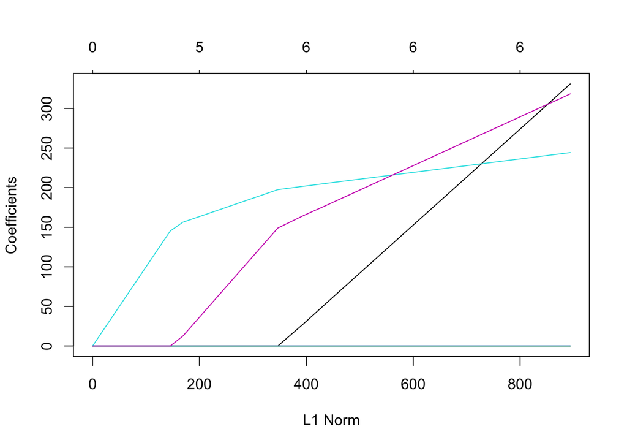

```r
x = model.matrix(logdata$`Y house price of unit area` ~ ., logdata)[,-1]
y = logdata[,7]

lass = glmnet(x, y, alpha = 1)
plot(lass)
```

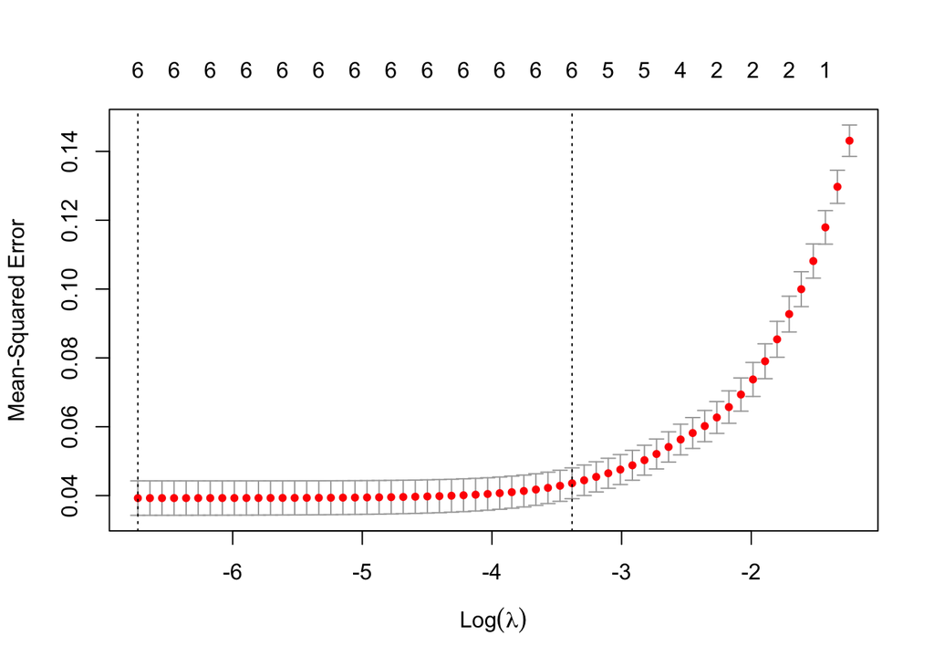

```r
cvlass = cv.glmnet(x,y, alpha = 1)
plot(cvlass)
```

```r
predict(lass, type = "coefficients", s = cvlass$lambda.1se)
```

```
## 7 x 1 sparse Matrix of class "dgCMatrix"
##                                                     s1
## (Intercept)                              -2.215320e+03
## `X1 transaction date`                     8.123465e+01
## `X2 house age`                           -5.069044e-02
## `X3 distance to the nearest MRT station` -1.526227e-01
## `X4 number of convenience stores`         3.113539e-02
## `X5 latitude`                             2.092239e+02
## `X6 longitude`                            1.914432e+02
```

# Extra points problem: using higher order terms (10 points)

*Evaluate the impact of adding non-linear terms to the model. Describe which terms, if any, warrant addition to the model and what is the evidence supporting their inclusion. Evaluate, present and discuss the effect of their incorporation on model coefficients and test error estimated by resampling.*